# Econometria Aplicada à Finanças Aula 7

Mestrado Profissional em Administração

Prof. Dr. Washington S. da Silva

IFMG — Campus Formiga

15 de setembro de 2026

Abertura

## Programação da aula

### Aula anterior

- Testes de Quebra Estrutural

### Hoje

- Diagnóstico do Modelo Linear

> “Science is what we understand well enough to explain to a computer. Art is everything else we do.”

> — Donald E. Knuth

“Ciência é aquilo que compreendemos bem o suficiente para explicar a um computador. Arte é tudo o mais que fazemos.”(Tradução livre)

Representação matricial e MQO

Do modelo à implementação computacional

## O mesmo modelo, em forma matricial

O modelo de regressão múltipla

$$y_i
=
\beta_0
+
\beta_1 x_{i1}
+
\cdots
+
\beta_p x_{ip}
+
\varepsilon_i,
\qquad i = 1,\ldots,n,$$

pode ser escrito, para todas as observações, como

$$\boxed{
\underset{n \times 1}{\mathbf{y}}
=
\underset{n \times (p+1)}{\mathbf{X}}
\underset{(p+1) \times 1}{\boldsymbol{\beta}}
+
\underset{n \times 1}{\boldsymbol{\varepsilon}}
}$$

$$\begin{pmatrix}
y_1\\
y_2\\
\vdots\\
y_n
\end{pmatrix}
=
\begin{pmatrix}
1 & x_{11} & \cdots & x_{1p}\\
1 & x_{21} & \cdots & x_{2p}\\
\vdots & \vdots & \ddots & \vdots\\
1 & x_{n1} & \cdots & x_{np}
\end{pmatrix}
\begin{pmatrix}
\beta_0\\
\beta_1\\
\vdots\\
\beta_p
\end{pmatrix}
+
\begin{pmatrix}
\varepsilon_1\\
\varepsilon_2\\
\vdots\\
\varepsilon_n
\end{pmatrix}.$$

- $n$: número de observações;
- $p$: número de variáveis explicativas;
- $x_{ij}$: valor da variável explicativa $j$ para a observação $i$.

**Cada linha de $\mathbf{X}$ representa uma observação; cada coluna corresponde a um coeficiente de $\boldsymbol{\beta}$.**

## Dados `gpa1`

Os dados `gpa1`, do pacote `wooldridge`, foram obtidos a partir de uma pesquisa com estudantes da **MSU**, realizada no segundo semestre de 1994.

- **141 observações**;
- **29 variáveis** sobre características acadêmicas e pessoais dos estudantes.

Neste bloco, utilizaremos três variáveis:

- `colGPA`: GPA do estudante na MSU;
- `hsGPA`: GPA do estudante no ensino médio;
- `ACT`: pontuação no teste de desempenho (`achievement score`).

Estimaremos o modelo

$$\text{colGPA}_i
=
\beta_0
+
\beta_1\text{hsGPA}_i
+
\beta_2\text{ACT}_i
+
\varepsilon_i.$$

## Onde está $\mathbf{X}$ quando usamos `lm()`?

Quando especificamos um modelo em R, a fórmula é convertida em uma **matriz do modelo**.

```r
# carrega o pacote contendo os dados
library(wooldridge)

# Carrega os dados usados no exemplo.
data(gpa1, package = "wooldridge")

# Estima o modelo especificado pela fórmula:
# colGPA = beta_0 + beta_1 hsGPA + beta_2 ACT + erro.
modelo <- lm(colGPA ~ hsGPA + ACT, data = gpa1)

# Extrai a matriz X construída pelo R a partir da
# fórmula do modelo.
X <- model.matrix(modelo)

# Mostra as 5 primeiras linhas da matriz X.
head(X, 5)
```

```
  (Intercept) hsGPA ACT
1           1   3.0  21
2           1   3.2  24
3           1   3.6  26
4           1   3.5  27
5           1   3.9  28
```

$$\boxed{
\texttt{formula + data}
\longrightarrow
\mathbf{X}
}$$

A matriz possui as colunas:

- `(Intercept)`;
- `hsGPA`;
- `ACT`.

A fórmula é uma interface conveniente para especificar a matriz usada na estimação.

## O que significa independência linear?

A matriz do modelo possui $p+1$ colunas:

$$\mathbf{X}
=
\begin{pmatrix}
\mathbf{1} & \mathbf{x}_1 & \mathbf{x}_2 & \cdots & \mathbf{x}_p
\end{pmatrix}.$$

Uma coluna é uma **combinação linear** de outras quando pode ser construída exatamente multiplicando essas colunas por números e somando os resultados.

Por exemplo,

$$\mathbf{x}_3
=
2\mathbf{x}_1-\mathbf{x}_2.$$

Nesse caso, $\mathbf{x}_3$ não acrescenta informação linear nova: ela pode ser reconstruída exatamente a partir de $\mathbf{x}_1$ e $\mathbf{x}_2$.

As colunas de $\mathbf{X}$ são **linearmente independentes** quando nenhuma delas pode ser escrita exatamente como combinação linear das demais.

## O que é o posto de uma matriz?

O **posto de colunas** de uma matriz é o número de colunas linearmente independentes.

Usaremos $\operatorname{rank}(\mathbf{X})$ para representar o posto de $\mathbf{X}$.

Como

$$\mathbf{X}\in\mathbb{R}^{n\times(p+1)},$$

a matriz possui $p+1$ colunas e seu posto não pode ser maior que $p+1$.

Se todas as $p+1$ colunas forem linearmente independentes,

$$\boxed{\operatorname{rank}(\mathbf{X})=p+1}$$

e dizemos que $\mathbf{X}$ possui **posto completo de colunas**.

Se houver uma relação linear exata entre as colunas,

$$\operatorname{rank}(\mathbf{X})<p+1,$$

e $\mathbf{X}$ não possui posto completo de colunas.

## Matrizes inversíveis e singulares

Uma matriz quadrada $\mathbf{A}$ é **inversível** quando existe uma matriz $\mathbf{A}^{-1}$ tal que

$$\mathbf{A}^{-1}\mathbf{A}
=
\mathbf{A}\mathbf{A}^{-1}
=
\mathbf{I},$$

onde $\mathbf{I}$ é a **matriz identidade**, com $1$ na diagonal principal e $0$ nas demais posições.

Se uma matriz quadrada **não possui inversa**, dizemos que ela é **singular**.

Denotamos por $\mathbf{X}^{\mathsf T}$ a **transposta** de $\mathbf{X}$, obtida trocando suas linhas por colunas.

Como

$$\mathbf{X}\in\mathbb{R}^{n\times(p+1)},$$

temos

$$\mathbf{X}^{\mathsf T}\mathbf{X}
\in
\mathbb{R}^{(p+1)\times(p+1)},$$

portanto $\mathbf{X}^{\mathsf T}\mathbf{X}$ é uma matriz quadrada.

**Quando essa matriz é inversível?**

## Por que o posto completo importa para o MQO?

Se

$$\operatorname{rank}(\mathbf{X})=p+1,$$

então todas as colunas de $\mathbf{X}$ são linearmente independentes.

Nesse caso,

$$\boxed{\mathbf{X}^{\mathsf T}\mathbf{X}\text{ é inversível}}$$

e existe uma **solução única de MQO para os coeficientes nessa parametrização**.

Se, ao contrário,

$$\operatorname{rank}(\mathbf{X})<p+1,$$

então $\mathbf{X}^{\mathsf T}\mathbf{X}$ é singular e não existe uma solução única para todos os coeficientes nessa parametrização.

$$\boxed{
\text{posto completo}
\;\Longrightarrow\;
\mathbf{X}^{\mathsf T}\mathbf{X}\text{ inversível}
\;\Longrightarrow\;
\text{solução de MQO única}
}$$

## Parâmetros, candidatos e estimativa de MQO

No modelo

$$\mathbf{y}
=
\mathbf{X}\boldsymbol{\beta}
+
\boldsymbol{\varepsilon},$$

os parâmetros estão reunidos no vetor

$$\boxed{
\boldsymbol{\beta}
=
\begin{pmatrix}
\beta_0\\
\beta_1\\
\vdots\\
\beta_p
\end{pmatrix}
\in
\mathbb{R}^{p+1}
}$$

Para procurar os valores que melhor ajustam o modelo aos dados, consideramos um vetor qualquer de candidatos:

$$\mathbf{b}
=
\begin{pmatrix}
b_0\\
b_1\\
\vdots\\
b_p
\end{pmatrix}
\in
\mathbb{R}^{p+1}.$$

- $\boldsymbol{\beta}$: vetor de parâmetros do modelo;
- $\mathbf{b}$: um vetor qualquer de valores candidatos;
- $\widehat{\boldsymbol{\beta}}$: valor de $\mathbf{b}$ escolhido pelo MQO.

## MQO como problema de minimização

Para um vetor candidato $\mathbf{b}$, a diferença entre os valores observados e os valores ajustados é

$$\mathbf{y}-\mathbf{X}\mathbf{b}.$$

A soma dos quadrados dessas diferenças é

$$S(\mathbf{b})
=
(\mathbf{y}-\mathbf{X}\mathbf{b})^{\mathsf T}
(\mathbf{y}-\mathbf{X}\mathbf{b}).$$

O método dos mínimos quadrados escolhe o vetor $\mathbf{b}$ que torna essa quantidade a menor possível:

$$\boxed{
\widehat{\boldsymbol{\beta}}
=
\underset{\mathbf{b}\in\mathbb{R}^{p+1}}{\arg\min}
\;
S(\mathbf{b})
}$$

$\arg\min$ indica o valor de $\mathbf{b}$ que minimiza $S(\mathbf{b})$.

## Da minimização às equações normais

Partimos da função que queremos minimizar:

$$S(\mathbf{b})
=
(\mathbf{y}-\mathbf{X}\mathbf{b})^{\mathsf T}
(\mathbf{y}-\mathbf{X}\mathbf{b}).$$

As condições de primeira ordem para o mínimo levam ao sistema

$$\boxed{
\mathbf{X}^{\mathsf T}\mathbf{X}
\widehat{\boldsymbol{\beta}}
=
\mathbf{X}^{\mathsf T}\mathbf{y}
}$$

denominado **equações normais do MQO**.

Resolver esse sistema significa encontrar os coeficientes que minimizam $S(\mathbf{b})$.

## A solução matricial do MQO

As equações normais são:

$$\mathbf{X}^{\mathsf T}\mathbf{X}
\widehat{\boldsymbol{\beta}}
=
\mathbf{X}^{\mathsf T}\mathbf{y}.$$

Como $\mathbf{X}$ possui posto completo de colunas, $\mathbf{X}^{\mathsf T}\mathbf{X}$ é inversível.

Assim,

$$\boxed{
\widehat{\boldsymbol{\beta}}
=
(\mathbf{X}^{\mathsf T}\mathbf{X})^{-1}
\mathbf{X}^{\mathsf T}\mathbf{y}
}$$

Esta é a **expressão matricial do estimador de MQO**.

## Da fórmula matricial para o R

Queremos calcular

$$\widehat{\boldsymbol{\beta}}
=
(\mathbf{X}^{\mathsf T}\mathbf{X})^{-1}
\mathbf{X}^{\mathsf T}\mathbf{y}.$$

```r
# Vetor da variável dependente y.
y <- gpa1$colGPA

# X'X: t() calcula a transposta de X
# e %*% realiza multiplicação matricial.
XtX <- t(X) %*% X

# X'y.
Xty <- t(X) %*% y

# (X'X)^(-1) X'y.
# solve(XtX) calcula a inversa de XtX neste caso.
beta_formula <- solve(XtX) %*% Xty
beta_formula
```

```
                   [,1]
(Intercept) 1.286327767
hsGPA       0.453455885
ACT         0.009426012
```

## Uma forma mais compacta em R

Em R, `crossprod()` permite calcular produtos envolvendo a transposta de uma matriz sem escrever `t()` explicitamente.

Assim, $\mathbf{X}^{\mathsf T}\mathbf{X}$ pode ser escrito como

```r
crossprod(X)
```

em vez de

```r
t(X) %*% X
```

Da mesma forma, $\mathbf{X}^{\mathsf T}\mathbf{y}$ pode ser escrito como

```r
crossprod(X, y)
```

em vez de

```r
t(X) %*% y
```

O cálculo do MQO fica mais compacto:

```r
# (X'X)^(-1) X'y.
beta_crossprod <- solve(crossprod(X)) %*% crossprod(X, y)

beta_crossprod
```

```
                   [,1]
(Intercept) 1.286327767
hsGPA       0.453455885
ACT         0.009426012
```

## A fórmula teórica não é o algoritmo

A expressão

$$\widehat{\boldsymbol{\beta}}
=
(\mathbf{X}^{\mathsf T}\mathbf{X})^{-1}
\mathbf{X}^{\mathsf T}\mathbf{y}$$

**caracteriza o estimador de MQO**.

Ela responde à pergunta: **Qual é a solução matemática do problema de mínimos quadrados?** Mas não determina a melhor forma de calcular essa solução no computador.

Uma implementação direta da fórmula exige formar: $\mathbf{X}^{\mathsf T}\mathbf{X}$ e trabalhar com essa matriz.

Diferentes formas de calcular a mesma solução matemática podem ter comportamentos numéricos diferentes.

Para entender por que isso importa, precisamos primeiro examinar uma propriedade da matriz $\mathbf{X}$:

$$\boxed{\text{condicionamento numérico}}$$

## O que significa condicionamento numérico?

O **condicionamento** descreve quão sensível é um problema matemático a pequenas perturbações nos dados.

Um problema é **bem condicionado** quando pequenas alterações nos dados produzem pequenas alterações na solução.

Um problema é **mal condicionado** quando pequenas alterações nos dados podem produzir alterações relativamente grandes na solução.

No nosso caso, queremos saber quão sensíveis podem ser os cálculos de mínimos quadrados às características da matriz $\mathbf{X}$.

## Valores singulares de $\mathbf{X}$

A matriz $\mathbf{X}$ possui números associados a ela chamados **valores singulares**.

Eles são sempre não negativos e ajudam a resumir propriedades numéricas importantes da matriz $\mathbf{X}$.

Vamos precisar apenas de dois:

$$\sigma_{\max}(\mathbf{X})
\qquad\text{e}\qquad
\sigma_{\min}(\mathbf{X}),$$

o maior e o menor valor singular de $\mathbf{X}$.

Quando $\mathbf{X}$ possui posto completo de colunas,

$$\sigma_{\min}(\mathbf{X})>0.$$

A relação entre o maior e o menor valor singular será usada para medir o **condicionamento** de $\mathbf{X}$.

## O número de condição de $\mathbf{X}$

Para medir o condicionamento de $\mathbf{X}$, usaremos o **número de condição na norma 2**, definido pela razão entre seu maior e seu menor valor singular:

$$\boxed{
\kappa(\mathbf{X})
=
\frac{\sigma_{\max}(\mathbf{X})}
{\sigma_{\min}(\mathbf{X})}
}$$

Como $\mathbf{X}$ possui posto completo de colunas,

$$\sigma_{\max}(\mathbf{X})
\geq
\sigma_{\min}(\mathbf{X})>0,$$

e, portanto,

$$\kappa(\mathbf{X})\geq 1.$$

- $\kappa(\mathbf{X})$ próximo de $1$: menor sensibilidade a pequenas perturbações;
- quanto maior $\kappa(\mathbf{X})$, **pior o condicionamento e maior a sensibilidade potencial**.

## Condicionamento e proximidade da perda de posto

Quando as colunas de $\mathbf{X}$ se tornam **quase linearmente dependentes**, o menor valor singular diminui:

$$\sigma_{\min}(\mathbf{X}) \longrightarrow 0.$$

Como

$$\kappa(\mathbf{X})
=
\frac{\sigma_{\max}(\mathbf{X})}
{\sigma_{\min}(\mathbf{X})},$$

um valor cada vez menor de $\sigma_{\min}(\mathbf{X})$ faz o número de condição aumentar.

No caso limite, existe uma relação linear exata entre as colunas:

$$\operatorname{rank}(\mathbf{X}) < p+1
\quad\Longleftrightarrow\quad
\sigma_{\min}(\mathbf{X}) = 0.$$

Nesse caso, teoricamente,

$$\boxed{
\kappa(\mathbf{X})=\infty
}$$

e $\mathbf{X}$ perde posto completo de colunas.

## Formar $\mathbf{X}^{\mathsf T}\mathbf{X}$ piora o condicionamento

Quando $\mathbf{X}$ possui posto completo de colunas,

$$\boxed{
\kappa(\mathbf{X}^{\mathsf T}\mathbf{X})
=
\kappa(\mathbf{X})^2
}$$

Isso significa que o número de condição é **elevado ao quadrado** quando passamos de $\mathbf{X}$ para $\mathbf{X}^{\mathsf T}\mathbf{X}$.

Por exemplo,

$$\kappa(\mathbf{X})=100
\quad\Longrightarrow\quad
\kappa(\mathbf{X}^{\mathsf T}\mathbf{X})=10\,000.$$

Portanto, se $\mathbf{X}$ já estiver mal condicionada, formar $\mathbf{X}^{\mathsf T}\mathbf{X}$ torna o condicionamento substancialmente pior.

**Esse é um dos motivos para preferirmos métodos que trabalham diretamente com $\mathbf{X}$ nos cálculos de mínimos quadrados.**

## Comparando o condicionamento com R

Vamos calcular o número de condição da matriz $\mathbf{X}$ do modelo estimado com os dados `gpa1` e compará-lo ao de $\mathbf{X}^{\mathsf T}\mathbf{X}$.

A função `kappa()` calcula o número de condição de uma matriz.

```r
# Número de condição de X.
# exact = TRUE usa o cálculo exato baseado nos valores singulares.
kappa_X <- kappa(X, exact = TRUE)

# Número de condição de X'X.
kappa_XtX <- kappa(crossprod(X), exact = TRUE)

kappa_X
```

```
[1] 298.0027
```

```r
kappa_XtX
```

```
[1] 88805.62
```

Como `crossprod(X)` calcula $\mathbf{X}^{\mathsf T}\mathbf{X}$, esperamos que

$$\kappa(\mathbf{X}^{\mathsf T}\mathbf{X})
=
\kappa(\mathbf{X})^2.$$

Podemos verificar:

```r
kappa_X^2
```

```
[1] 88805.62
```

**O exemplo mostra numericamente que formar $\mathbf{X}^{\mathsf T}\mathbf{X}$ piora o condicionamento já presente em $\mathbf{X}$.**

## Comparando o condicionamento com R

- O número de condição também depende da **escala das colunas** de $\mathbf{X}$.
- Por isso, um valor elevado não deve ser interpretado mecanicamente como uma medida de multicolinearidade.

## Trabalhando diretamente com $\mathbf{X}$: decomposição QR

Em vez de formar $\mathbf{X}^{\mathsf T}\mathbf{X}$, podemos trabalhar diretamente com $\mathbf{X}$ por meio de uma **decomposição matricial**.

Uma decomposição representa uma matriz como o produto de matrizes com propriedades úteis para os cálculos.

Para

$$\mathbf{X}\in\mathbb{R}^{n\times(p+1)}$$

com posto completo de colunas, usaremos a **decomposição QR reduzida**:

$$\boxed{
\mathbf{X}
=
\mathbf{Q}\mathbf{R}
}$$

Na forma reduzida,

$$\underset{n\times(p+1)}{\mathbf{Q}}
\qquad\text{e}\qquad
\underset{(p+1)\times(p+1)}{\mathbf{R}}.$$

A matriz $\mathbf{Q}$ contém apenas as $p+1$ colunas necessárias para representar $\mathbf{X}$.

**A matriz $\mathbf{X}$ não muda: ela está sendo representada de uma forma mais conveniente para os cálculos de mínimos quadrados.**

## O que torna $\mathbf{Q}$ especial?

Na decomposição QR reduzida,

$$\mathbf{X}=\mathbf{Q}\mathbf{R},$$

as colunas de $\mathbf{Q}$ são **ortonormais**.

Isso significa que cada coluna possui comprimento igual a $1$:

$$\mathbf{q}_j^{\mathsf T}\mathbf{q}_j=1,$$

e duas colunas distintas satisfazem

$$\mathbf{q}_j^{\mathsf T}\mathbf{q}_k=0,
\qquad j\neq k.$$

Essas propriedades podem ser reunidas em uma única expressão:

$$\boxed{
\mathbf{Q}^{\mathsf T}\mathbf{Q}
=
\mathbf{I}_{p+1}
}$$

onde $\mathbf{I}_{p+1}$ é a matriz identidade: possui $1$ na diagonal principal e $0$ nas demais posições.

## O que torna $\mathbf{R}$ especial?

Na decomposição QR reduzida, $\mathbf{R}$ é uma matriz **triangular superior**:

$$\mathbf{R}
=
\begin{pmatrix}
r_{11} & r_{12} & \cdots & r_{1,p+1}\\
0 & r_{22} & \cdots & r_{2,p+1}\\
\vdots & \ddots & \ddots & \vdots\\
0 & \cdots & 0 & r_{p+1,p+1}
\end{pmatrix}.$$

Isso significa que todos os elementos abaixo da diagonal principal são iguais a zero.

Como $\mathbf{X}$ possui posto completo de colunas, os elementos da diagonal de $\mathbf{R}$ são diferentes de zero.

Por isso, um sistema do tipo

$$\mathbf{R}\mathbf{b}=\mathbf{c}$$

pode ser resolvido começando pela última equação e seguindo para as anteriores.

Esse procedimento é chamado de **substituição retroativa**.

**Essa estrutura permitirá resolver diretamente o sistema que determina os coeficientes de MQO.**

## Da decomposição QR ao sistema do MQO

As equações normais são

$$\mathbf{X}^{\mathsf T}\mathbf{X}
\widehat{\boldsymbol{\beta}}
=
\mathbf{X}^{\mathsf T}\mathbf{y}.$$

**1. Substituímos $\mathbf{X}=\mathbf{Q}\mathbf{R}$ e usamos $(\mathbf{Q}\mathbf{R})^{\mathsf T} =\mathbf{R}^{\mathsf T}\mathbf{Q}^{\mathsf T}$:**

$$\mathbf{R}^{\mathsf T}
\mathbf{Q}^{\mathsf T}
\mathbf{Q}
\mathbf{R}
\widehat{\boldsymbol{\beta}}
=
\mathbf{R}^{\mathsf T}
\mathbf{Q}^{\mathsf T}\mathbf{y}.$$

**2. Como as colunas de $\mathbf{Q}$ são ortonormais, $\mathbf{Q}^{\mathsf T}\mathbf{Q}=\mathbf{I}$:**

$$\mathbf{R}^{\mathsf T}\mathbf{R}
\widehat{\boldsymbol{\beta}}
=
\mathbf{R}^{\mathsf T}\mathbf{Q}^{\mathsf T}\mathbf{y}.$$

**3. Como $\mathbf{R}$ é inversível, $\mathbf{R}^{\mathsf T}$ também é. Multiplicamos os dois lados, à esquerda, por $(\mathbf{R}^{\mathsf T})^{-1}$:**

$$(\mathbf{R}^{\mathsf T})^{-1}
\mathbf{R}^{\mathsf T}
\mathbf{R}
\widehat{\boldsymbol{\beta}}
=
(\mathbf{R}^{\mathsf T})^{-1}
\mathbf{R}^{\mathsf T}
\mathbf{Q}^{\mathsf T}\mathbf{y}.$$

Como $(\mathbf{R}^{\mathsf T})^{-1}\mathbf{R}^{\mathsf T}=\mathbf{I}$,

$$\boxed{
\mathbf{R}\widehat{\boldsymbol{\beta}}
=
\mathbf{Q}^{\mathsf T}\mathbf{y}
}$$

## Como a QR simplifica o cálculo do MQO?

A decomposição QR transforma o problema em resolver

$$\boxed{
\mathbf{R}\widehat{\boldsymbol{\beta}}
=
\mathbf{Q}^{\mathsf T}\mathbf{y}
}$$

Já sabemos que $\mathbf{R}$ é triangular superior.

Assim, os coeficientes podem ser obtidos por **substituição retroativa**, começando pela última equação e seguindo para as anteriores.

O cálculo pode trabalhar diretamente com a decomposição de $\mathbf{X}$:

$$\mathbf{X}
\longrightarrow
\mathbf{Q},\mathbf{R}
\longrightarrow
\mathbf{R}\widehat{\boldsymbol{\beta}}
=
\mathbf{Q}^{\mathsf T}\mathbf{y}.$$

**Não é necessário formar $\mathbf{X}^{\mathsf T}\mathbf{X}$ nem calcular explicitamente $(\mathbf{X}^{\mathsf T}\mathbf{X})^{-1}$.**

## A decomposição QR é usada por `lm()`

R utiliza, por padrão, a **decomposição QR** para calcular os coeficientes de um modelo estimado com `lm()`.

Podemos reproduzir explicitamente esse cálculo a partir da matriz $\mathbf{X}$:

```r
# calcula a decomposição QR da matriz X
qr_X <- qr(X)

# obtém os coeficientes de MQO a partir da decomposição
beta_qr <- qr.coef(qr_X, y)

beta_qr
```

```
(Intercept)       hsGPA         ACT
1.286327767 0.453455885 0.009426012
```

Os coeficientes podem ser comparados com os retornados por `lm()`:

```r
cbind(
  `QR explícita` = beta_qr,
  `lm()` = coef(modelo)
)
```

```
            QR explícita        lm()
(Intercept)  1.286327767 1.286327767
hsGPA        0.453455885 0.453455885
ACT          0.009426012 0.009426012
```

**Não estamos usando dois estimadores diferentes.**

## Mesma solução matemática, caminhos computacionais diferentes

A expressão

$$\widehat{\boldsymbol{\beta}}
=
(\mathbf{X}^{\mathsf T}\mathbf{X})^{-1}
\mathbf{X}^{\mathsf T}\mathbf{y}$$

**caracteriza matematicamente o estimador de MQO**.

Mas não precisamos calcular os coeficientes formando $\mathbf{X}^{\mathsf T}\mathbf{X}$ e sua inversa.

Com a decomposição QR, trabalhamos diretamente com $\mathbf{X}$ e resolvemos

$$\boxed{
\mathbf{R}\widehat{\boldsymbol{\beta}}
=
\mathbf{Q}^{\mathsf T}\mathbf{y}
}$$

Em aritmética exata, os dois caminhos levam à mesma solução de mínimos quadrados.

Na computação numérica, porém, formar $\mathbf{X}^{\mathsf T}\mathbf{X}$ piora o condicionamento:

$$\kappa(\mathbf{X}^{\mathsf T}\mathbf{X})
=
\kappa(\mathbf{X})^2.$$

**A QR não torna uma matriz mal condicionada em bem condicionada: ela evita agravar desnecessariamente o condicionamento ao formar $\mathbf{X}^{\mathsf T}\mathbf{X}$.**

## Um resultado computacional também precisa ser compreendido

A fórmula matemática não determina, sozinha, **como o computador realizará o cálculo**. Como vimos com MQO, formar $\mathbf{X}^{\mathsf T}\mathbf{X}$ ou trabalhar diretamente com $\mathbf{X}$ por meio da decomposição QR conduz à mesma solução matemática, mas não às mesmas propriedades numéricas.

A confiabilidade de procedimentos estatísticos implementados em software é, portanto, uma questão que pode e deve ser **avaliada empiricamente**. McCullough propôs benchmarks específicos para esse propósito (McCullough, 1998).

Problemas documentados em versões históricas do Microsoft Excel mostram que a popularidade de uma ferramenta, por si só, **não garante a acurácia de seus procedimentos estatísticos** (McCullough e Heiser, 2008; McCullough e Wilson, 2005).

Para o econometrista aplicado, isso reforça a importância de combinar:

- conhecimento **econométrico**;
- fundamentos de **álgebra linear numérica e programação**;
- uso de ferramentas apropriadas, programáveis e reproduzíveis;
- capacidade de **avaliar criticamente os resultados produzidos pelo software**.

**Não precisamos implementar todos os algoritmos que usamos, mas precisamos saber o suficiente para não tratar o software como uma caixa-preta infalível.**

## O que a representação matricial nos mostrou?

Escrever o modelo como

$$\mathbf{y}
=
\mathbf{X}\boldsymbol{\beta}
+
\boldsymbol{\varepsilon}$$

permite enxergar propriedades do modelo que não aparecem tão claramente na notação observação por observação.

Para que a solução de MQO seja única, $\mathbf{X}$ deve possuir posto completo de colunas:

$$\operatorname{rank}(\mathbf{X})=p+1.$$

Mesmo antes da perda de posto, relações lineares muito fortes entre as colunas podem tornar o problema mal condicionado:

$$\sigma_{\min}(\mathbf{X}) \downarrow
\quad\Longrightarrow\quad
\kappa(\mathbf{X}) \uparrow.$$

**Isso nos leva a uma questão econométrica importante: o que acontece quando as variáveis explicativas carregam pouca informação independente umas das outras?**

Multicolinearidade

## Da dependência exata à multicolinearidade elevada

Há duas situações diferentes quando as variáveis explicativas carregam informação linear semelhante.

### Dependência linear exata

Uma coluna de $\mathbf{X}$ pode ser escrita exatamente como combinação linear das demais:

$$\operatorname{rank}(\mathbf{X}) < p+1.$$

Não existe uma solução única para todos os coeficientes nessa parametrização.

### Relação forte, mas não exata

As regressoras podem estar fortemente relacionadas sem que exista uma relação linear exata:

$$\operatorname{rank}(\mathbf{X}) = p+1.$$

A solução de MQO continua sendo única nessa parametrização.

**Se o posto completo é preservado, por que a multicolinearidade elevada importa?**

## Por que isso é comum em dados econômico-financeiros?

Variáveis econômicas e financeiras frequentemente respondem aos mesmos **fatores subjacentes**.

Por exemplo, o **porte da unidade econômica** pode afetar várias regressoras simultaneamente:

- empresas maiores tendem a apresentar maiores valores de ativos, vendas, dívida e investimento;
- nos dados `rice5`, propriedades com mais área tendem também a utilizar mais trabalho e fertilizante.

Quando várias regressoras refletem o mesmo fator comum, elas tendem a **se mover juntas**.

Assim, uma regressora pode ser amplamente explicada pelas demais:

$$R_j^2 \uparrow
\quad\Longrightarrow\quad
\text{menos variação própria em } x_j.$$

Indicadores construídos a partir de **componentes contábeis comuns** também podem carregar informação parcialmente sobreposta.

**A questão central não é que as regressoras sejam relacionadas, mas quanto de informação independente resta em cada uma delas.**

## O problema não é viés, é precisão

Com posto completo e mantidas as demais hipóteses do teorema de Gauss–Markov,

$$\boxed{
\widehat{\boldsymbol{\beta}}_{\mathrm{MQO}}
\text{ continua BLUE}
}$$

A multicolinearidade não exata, por si só, **não torna os estimadores de MQO viesados**.

**Precisão** refere-se à variabilidade do estimador: quanto menor sua variância e seu **erro-padrão**, maior a precisão da estimativa.

O problema é que os dados podem conter pouca informação independente para estimar com precisão os coeficientes associados às regressoras.

**Ser o melhor estimador linear não viesado não significa ser estimado com grande precisão.**

## Quanto de $x_j$ realmente sobra?

Considere a **regressão auxiliar** de uma variável explicativa $x_j$ sobre as demais regressoras do modelo.

Depois da estimação, podemos escrever

$$\boxed{
x_{ij}
=
\widehat{x}_{ij}
+
\widehat{v}_{ij}
}$$

- $\widehat{x}_{ij}$: parte de $x_{ij}$ explicada linearmente pelas demais regressoras;
- $\widehat{v}_{ij}$: parte que permanece não explicada.

É essa **variação não explicada pelas demais regressoras** que fornece informação para estimar separadamente o coeficiente associado a $x_j$.

## Muita ou pouca informação independente?

### Baixa multicolinearidade

$$x_{ij}
=
\widehat{x}_{ij}
+
\underbrace{\widehat{v}_{ij}}_{\text{resíduo}}$$

$$\sum_i \widehat{v}_{ij}^{\,2}
\quad \text{relativamente maior}$$

**Mais variação própria em $x_j$**

### Alta multicolinearidade

$$x_{ij}
=
\widehat{x}_{ij}
+
\underbrace{\widehat{v}_{ij}}_{\text{resíduo}}$$

$$\sum_i \widehat{v}_{ij}^{\,2}
\quad \text{relativamente menor}$$

**Pouca variação própria em $x_j$**

Quanto mais as demais regressoras explicam $x_j$, menos informação independente resta para estimar seu coeficiente separadamente.

## Onde a correlação entra na variância?

Sob homocedasticidade, considere um modelo com duas variáveis explicativas. A variância do estimador de MQO de $\beta_2$, condicional às regressoras, é:

$$\boxed{
\operatorname{Var}
\left(
\widehat{\beta}_2 \mid \mathbf{X}
\right)
=
\frac{\sigma^2}
{
\left(1-r_{23}^2\right)
\displaystyle\sum_{i=1}^{n}
\left(x_{i2}-\bar{x}_2\right)^2
}
}$$

onde $r_{23}=\operatorname{corr}(x_2,x_3)$ é o coeficiente de correlação linear entre as duas variáveis explicativas.

Na regressão simples de $x_2$ sobre $x_3$, $r_{23}^2$ é o $R^2$: a proporção da variação de $x_2$ explicada linearmente por $x_3$.

Assim, $1-r_{23}^2$ representa a proporção da variação de $x_2$ que **permanece não explicada por $x_3$**.

Quanto mais $|r_{23}|$ se aproxima de $1$, menor essa parcela e **maior é a variância de $\widehat{\beta}_2$**.

## Quanto a correlação elevada infla a variância?

Mantendo a variância do erro, $\sigma^2$, e a variação de $x_2$ constantes, a correlação entre $x_2$ e $x_3$ multiplica a variância de $\widehat{\beta}_2$ pelo fator:

$$\boxed{
\frac{1}{1-r_{23}^2}
}$$

em relação ao caso $r_{23}=0$.

Se $r_{23}=0{,}90$, então $\frac{1}{1-0{,}90^2}\approx 5{,}3$:

**a variância é aproximadamente 5,3 vezes maior.**

Se $r_{23}=0{,}99$, então $\frac{1}{1-0{,}99^2}\approx 50{,}3$:

**a variância é aproximadamente 50,3 vezes maior.**

## Correlação entre pares não é suficiente

Com várias regressoras, $x_j$ pode estar fortemente relacionado a uma **combinação das demais variáveis**, mesmo sem apresentar correlação muito elevada com uma delas isoladamente.

Para avaliar quanto de $x_j$ é explicado conjuntamente pelas demais regressoras, estimamos a regressão auxiliar

$$x_{ij} = \alpha_0 + \sum_{k\neq j}\alpha_k x_{ik} + v_{ij}.$$

O $R_j^2$ dessa regressão mede a proporção da variação de $x_j$ explicada **conjuntamente pelas demais regressoras**.

## Do $R_j^2$ ao VIF

A partir do $R_j^2$ da regressão auxiliar, definimos o **fator de inflação da variância**:

$\displaystyle VIF_j = \frac{1}{1-R_j^2}$.

Se $R_j^2=0$, as demais regressoras não explicam a variação de $x_j$ e $VIF_j=1$: **não há inflação da variância associada à colinearidade**.

À medida que $R_j^2$ aumenta, menos variação própria resta em $x_j$ e o $VIF_j$ cresce.

Se $R_j^2 \rightarrow 1$, então $VIF_j \rightarrow \infty$.

## VIF e erro-padrão não são a mesma coisa

Na expressão clássica da variância, sob homocedasticidade, o $VIF_j$ mede quanto a variância de $\widehat{\beta}_j$ é multiplicada **em relação ao caso $R_j^2=0$**, mantidos os demais componentes constantes.

Como o erro-padrão é a raiz quadrada da variância, seu multiplicador é $\sqrt{VIF_j}$.

Por exemplo, se $VIF_j=10$, a variância é multiplicada por $10$ e o erro-padrão por $\sqrt{10}\approx 3{,}16$, em relação ao caso $R_j^2=0$.

## Dados `rice5`

Os dados `rice5`, do pacote `POE5Rdata`, formam um **painel com 44 firmas produtoras de arroz das Filipinas**, observadas em **1993 e 1994**.

- 44 firmas;
- 2 anos;
- 88 observações no conjunto completo.

Neste bloco, utilizaremos apenas as **44 observações de 1994** e quatro variáveis:

- `prod`: produção de arroz, em toneladas;
- `area`: área plantada com arroz, em hectares;
- `labor`: trabalho contratado e familiar, em dias-pessoa;
- `fert`: fertilizante aplicado, em quilogramas.

Os dados foram utilizados por O’Donnell e Griffiths (2006) em um estudo sobre produção de arroz nas Filipinas.

## Função de produção de arroz

Hill, Griffiths e Lim utilizam os dados para estimar uma função de produção do tipo log-log:

$$\ln(PROD)
=
\beta_1
+\beta_2\ln(AREA)
+\beta_3\ln(LABOR)
+\beta_4\ln(FERT)
+e.$$

Nesse modelo, os coeficientes associados a `area`, `labor` e `fert` representam elasticidades da produção em relação a esses insumos.

## Estimando o modelo em R

```r
data("rice5", package = "POE5Rdata")

# Mantém apenas as observações de 1994.
rice_1994 <- rice5 |>
  filter(year == 1994)

# Estima a função de produção.
modelo_arroz <- lm(log(prod) ~ log(area) + log(labor) + log(fert), data = rice_1994)

# Exibe os resultados da estimação.
broom::tidy(modelo_arroz)
```

```
# A tibble: 4 × 5
  term        estimate std.error statistic p.value
  <chr>          <dbl>     <dbl>     <dbl>   <dbl>
1 (Intercept)   -1.95      0.738     -2.64  0.0119
2 log(area)      0.211     0.182      1.16  0.254
3 log(labor)     0.378     0.255      1.48  0.147
4 log(fert)      0.343     0.128      2.68  0.0106
```

```r
# Exibe o coeficiente de determinação.
broom::glance(modelo_arroz) |>
  select(r.squared)
```

```
# A tibble: 1 × 1
  r.squared
      <dbl>
1     0.875
```

## O que encontramos na regressão principal?

| Variável | Estimativa | Erro-padrão | $p$-valor |
| --- | --- | --- | --- |
| `log(area)` | 0,2106 | 0,1821 | 0,2543 |
| `log(labor)` | 0,3776 | 0,2551 | 0,1466 |
| `log(fert)` | 0,3433 | 0,1280 | 0,0106 |

$R^2=0{,}8745$.

Apesar do elevado $R^2$, os coeficientes de `area` e `labor` são estimados com **baixa precisão individual**.

## Regressão auxiliar para `labor`

Para obter o $R_j^2$ associado a `labor`, estimamos `log(labor)` em função das demais regressoras do modelo.

```r
# Estima a regressão auxiliar para log(labor).
aux_labor <- lm(log(labor) ~ log(area) + log(fert), data = rice_1994)

# Exibe o R² da regressão auxiliar.
broom::glance(aux_labor) |>
  select(r.squared)
```

```
# A tibble: 1 × 1
  r.squared
      <dbl>
1     0.944
```

## Interpretação do $R_j^2$ auxiliar de `labor`

Na regressão auxiliar, $R_{\text{labor}}^2 \approx 0{,}9436$.

Assim, aproximadamente **94,4% da variação de `log(labor)`** é explicada linearmente por `log(area)` e `log(fert)`.

Restam apenas $1-0{,}9436=0{,}0564$, ou cerca de **5,6% da variação de `log(labor)`**, não explicados pelas demais regressoras.

Há, portanto, **pouca variação própria em `log(labor)`** para estimar separadamente seu coeficiente.

## Calculando o VIF manualmente

Para `labor`, usamos o $R^2$ da regressão auxiliar:

$VIF_{\text{labor}}=1/(1-R_{\text{labor}}^2)$.

```r
# Recupera o R² da regressão auxiliar.
r2_labor <- broom::glance(aux_labor)$r.squared

# Calcula manualmente o VIF de log(labor).
vif_labor <- 1 / (1 - r2_labor)

vif_labor
```

```
[1] 17.73385
```

Com $R_{\text{labor}}^2 \approx 0{,}9436$, obtemos $VIF_{\text{labor}} \approx 17{,}73$.

## VIFs das três regressoras

| Regressora | $R_j^2$ | VIF |
| --- | --- | --- |
| `log(area)` | 0,8907 | 9,15 |
| `log(labor)` | 0,9436 | 17,73 |
| `log(fert)` | 0,8699 | 7,68 |

A função `car::vif()` automatiza o mesmo cálculo para todas as regressoras:

```r
car::vif(modelo_arroz)
```

```
 log(area) log(labor)  log(fert)
  9.149377  17.733853   7.683995
```

## Como interpretar os valores do VIF?

O VIF pode ser lido a partir da proporção da variação de $x_j$ que é explicada pelas demais regressoras:

$\displaystyle VIF_j=\frac{1}{1-R_j^2}$.

| VIF | $R_j^2$ auxiliar | Interpretação |
| --- | --- | --- |
| $1$ | $0$ | nenhuma variação de $x_j$ é explicada pelas demais |
| $5$ | $0{,}80$ | 80% é explicada; resta 20% de variação própria |
| $10$ | $0{,}90$ | 90% é explicada; resta 10% de variação própria |
| $>10$ | $>0{,}90$ | resta menos de 10% de variação própria |

Por isso, valores como **5** e **10** aparecem frequentemente como referências informais: eles correspondem a níveis elevados de explicação de uma regressora pelas demais.

Mas essas referências **não são limites universais**.

Um VIF elevado é um sinal de pouca informação independente em $x_j$; não determina, sozinho, se a precisão é inadequada nem se o modelo deve ser modificado.

## Por que resta pouca informação independente em `rice5`?

Uma interpretação substantiva é que `area`, `labor` e `fert` refletem, em parte, o **porte da propriedade agrícola**.

Propriedades maiores tendem a:

- cultivar uma área maior;
- utilizar mais trabalho;
- aplicar mais fertilizante.

Assim, essas regressoras tendem a **se mover conjuntamente**.

Consequentemente, uma parte importante da variação de cada regressora pode ser explicada pelas demais.

Quanto maior essa parcela compartilhada, menos **variação própria** e menos **informação independente** restam para estimar separadamente seu coeficiente.

Essa interpretação é consistente com os elevados $R_j^2$ das regressões auxiliares e com os VIFs observados, mas não demonstra que o **porte** seja a única origem da multicolinearidade no modelo.

## Como interpretar o VIF sem uma regra mecânica?

Na expressão clássica da variância, o VIF indica quanto a **colinearidade entre uma regressora e as demais** infla a variância do estimador de seu coeficiente.

Quanto maior o $R_j^2$ da regressão auxiliar, menor a variação própria de $x_j$ e maior o $VIF_j$.

Mas um VIF elevado **não implica, por si só, que exista um problema que exija alterar o modelo**.

A questão relevante é se a colinearidade aumenta suficientemente os **erros-padrão**, reduzindo a **precisão das estimativas**, ou torna as estimativas excessivamente sensíveis.

## Evidência individual e evidência conjunta

Na função de produção de arroz, temos $R^2=0{,}8745$, mas:

- `log(area)`: $\widehat{\beta}=0{,}2106$, $p=0{,}2543$;
- `log(labor)`: $\widehat{\beta}=0{,}3776$, $p=0{,}1466$.

Agora considere a hipótese conjunta $H_0:\beta_{\text{area}}=\beta_{\text{labor}}=0$.

O teste produz $F(2,40)\approx 7{,}19$ e $p\approx 0{,}00215$.

**Baixa precisão das estimativas individuais não implica ausência de evidência conjunta sobre as regressoras.**

## Testando a hipótese conjunta com R

A hipótese pode ser testada diretamente com `car::linearHypothesis()`:

```r
car::linearHypothesis(
  modelo_arroz,
  c(
    "log(area) = 0",
    "log(labor) = 0"
  )
)
```

```
Linear hypothesis test:
log(area) = 0
log(labor) = 0

Model 1: restricted model
Model 2: log(prod) ~ log(area) + log(labor) + log(fert)

  Res.Df    RSS Df Sum of Sq      F   Pr(>F)
1     42 5.3357
2     40 3.9245  2    1.4112 7.1918 0.002147 **
---
Signif. codes:  0 '***' 0.001 '**' 0.01 '*' 0.05 '.' 0.1 ' ' 1
```

Resultado: $F(2,40)\approx 7{,}19$ e $p\approx 0{,}00215$.

Assim, rejeitamos $H_0:\beta_{\text{area}}=\beta_{\text{labor}}=0$.

## Como lidar com multicolinearidade elevada?

Não existe uma solução automática. A resposta depende do problema empírico, da informação disponível e da finalidade do modelo.

- **Obter mais e melhores dados**, especialmente observações que acrescentem variação independente às regressoras. Apenas aumentar a amostra pode ajudar pouco se as novas observações reproduzirem a mesma relação colinear.
- **Reavaliar a pergunta e o nível de desagregação**: se os dados não permitem separar determinados coeficientes com precisão, pode ser adequado reformular o problema ou combinar variáveis quando isso fizer sentido substantivo.
- **Incorporar informação externa confiável**, quando houver fundamento substantivo para impor restrições aos parâmetros. Por exemplo, retornos constantes à escala implicam $\beta_2+\beta_3+\beta_4=1.$
- Restrições incorretas podem reduzir a variância ao custo de introduzir viés.
- **Não remover regressoras mecanicamente** apenas para reduzir VIF ou erros-padrão. Se uma variável relevante for omitida e estiver relacionada às regressoras mantidas, os estimadores podem sofrer **viés por variável omitida**.

**Outras abordagens:** em problemas de previsão ou alta dimensionalidade, métodos de regularização, como **ridge** e **LASSO**, e métodos de redução de dimensão podem ser úteis, mas mudam o problema de estimação e não constituem uma correção automática da especificação econométrica.

## O diagnóstico não escolhe o modelo por nós

A multicolinearidade elevada pode **aumentar os erros-padrão e reduzir a precisão das estimativas**, mas:

- VIF elevado **não significa** que uma variável seja irrelevante;
- $p$-valor individual elevado **não significa** que a variável deva ser removida.

Excluir uma **variável relevante para a especificação do modelo** apenas para reduzir a multicolinearidade pode substituir um problema de precisão por um **problema de especificação**, como viés por variável omitida.

**Diante de multicolinearidade elevada, como decidir se a especificação do modelo deve ou não ser modificada?**

Multicolinearidade e Especificação do modelo

## Diagnóstico não é decisão de especificação

Escolher quais regressoras entram no modelo faz parte de sua **especificação**.

VIF, erros-padrão e $p$-valores fornecem informações sobre o comportamento das estimativas, mas **não determinam, isoladamente, quais variáveis devem ser incluídas ou excluídas**.

Também precisamos considerar **qual função cada variável desempenha no modelo**.

**Qual é a finalidade do modelo?**

## A finalidade do modelo importa

### Análise causal

O interesse está em **identificar e estimar o efeito causal de uma variável sobre $y$**.

A escolha das regressoras é essencial para essa finalidade, mas a interpretação causal também depende de **hipóteses de identificação**.

### Previsão

O interesse está em **prever $y$ com precisão**.

As regressoras são escolhidas pelo quanto contribuem para a previsão, mesmo que seus efeitos causais não sejam o objeto da análise.

Portanto, a especificação adequada depende também da **finalidade do modelo**.

## Omitir uma variável relevante pode introduzir viés

Suponha que $z$ pertença ao modelo populacional, com coeficiente diferente de zero, e esteja relacionada à regressora $x$.

Se $z$ é omitida, sua contribuição passa a fazer parte do novo termo de erro.

Como $x$ e $z$ estão relacionadas, $x$ também passa a estar relacionada a esse erro.

Nesse caso, parte da contribuição de $z$ pode ser **atribuída a $x$**, tornando enviesada a estimativa de seu coeficiente.

Sob as hipóteses usuais para o modelo corretamente especificado, esse problema também persiste em grandes amostras: o estimador é **inconsistente**.

**Retirar uma variável relevante para ganhar precisão pode criar um problema de especificação.**

## Incluir regressoras irrelevantes também tem um custo

Uma variável é **irrelevante** quando, controladas as demais regressoras, ela não tem efeito parcial sobre $y$ na população — no modelo linear, seu coeficiente populacional é zero.

Como não conhecemos esse coeficiente, **teoria, conhecimento substantivo e compreensão da relação estudada** ajudam a avaliar quais variáveis fazem sentido na especificação.

Incluir regressoras irrelevantes, especialmente quando relacionadas às demais, pode aumentar a **variância e os erros-padrão** dos coeficientes estimados.

**Erro-padrão maior significa menor precisão.**

Assim, acrescentar variáveis indiscriminadamente também pode prejudicar a estimação — nesse caso, pela **perda de precisão**, e não por viés.

## Viés e precisão são problemas diferentes

### Omitir variável relevante

Nas condições pertinentes, a omissão pode fazer com que parte de seu efeito seja atribuída às regressoras incluídas.

**Pode produzir viés e inconsistência.**

### Incluir variável irrelevante

Especialmente quando relacionada às demais regressoras, sua inclusão pode elevar variâncias e erros-padrão.

**Pode reduzir a precisão.**

**Viés e perda de precisão são problemas diferentes** — e esse contraste não gera uma regra automática sobre incluir ou excluir variáveis.

## Um valor-p não escolhe a especificação

Um coeficiente estimado **estatisticamente insignificante** é compatível com situações diferentes:

- o coeficiente populacional pode ser zero e a variável, irrelevante;
- o coeficiente populacional pode ser diferente de zero, mas estimado com pouca precisão.

Com multicolinearidade elevada:

**erro-padrão maior** → **menor precisão** → **menor capacidade de detectar um efeito existente**.

Portanto, um **valor-p elevado não demonstra, por si só, que uma variável é irrelevante**.

## Significância estatística não é relevância

A decisão sobre uma variável não depende apenas de seu **valor-p**.

Teoria, conhecimento substantivo e evidência estatística devem ser considerados em conjunto ao avaliar a especificação.

Isso leva a uma questão adicional:

**uma variável pode ser importante mesmo quando seu próprio coeficiente não é o nosso principal interesse?**

## O que é uma variável de controle?

Uma **variável de controle** é incluída para contribuir para uma especificação adequada do modelo, mesmo quando seu próprio coeficiente não é o principal objeto de interesse.

- **Variável de interesse:** seu coeficiente é o que queremos principalmente estimar e interpretar.
- **Variável de controle:** é incluída pelo papel que desempenha na especificação e na estimação do coeficiente de interesse.

Um controle pode ser **relevante por si mesmo**: “controle” descreve sua função na análise, e não significa “variável irrelevante”.

Seu uso pode ajudar a evitar **viés no coeficiente de interesse** decorrente da omissão de fatores relevantes.

Por isso, seu próprio $p$-valor não fornece uma regra mecânica para excluí-lo.

## Quando o fator relevante é observado

Suponha que queremos avaliar o efeito do **tamanho da turma** sobre o **desempenho escolar**.

O contexto socioeconômico também pode afetar o desempenho e estar relacionado ao tamanho das turmas.

Se dispomos de uma medida observada desse contexto, ela pode entrar **diretamente no modelo como controle**.

- **Resultado:** desempenho escolar
- **Variável de interesse:** tamanho da turma
- **Controle:** contexto socioeconômico

Controlar o contexto socioeconômico ajuda a separar o efeito associado ao tamanho da turma das diferenças socioeconômicas entre as escolas.

**E se o fator relevante que gostaríamos de controlar não puder ser observado diretamente?**

## Quando o fator relevante não é observado

Queremos estudar a relação entre **educação** e **salário**, mas existe um problema: a **habilidade** pode

- afetar o salário; e
- estar relacionada à educação.

Se a habilidade não observada for omitida, parte de sua contribuição pode ser atribuída ao coeficiente de `educ`.

Não observamos diretamente a habilidade, mas observamos `score`, um índice construído a partir de testes de aptidão.

Podemos utilizar `score` como uma **proxy para a habilidade**.

A ideia é que `score` capture informação sobre a habilidade não observada e, assim, ajude a controlar diferenças de habilidade entre indivíduos.

## O que esperamos do escore como proxy?

O problema da habilidade omitida surge porque ela pode afetar o salário e, ao mesmo tempo, estar relacionada à educação.

Para que `score` ajude a eliminar esse viés, ele **não precisa medir perfeitamente a habilidade**.

Precisamos que, depois de controlar por experiência e `score`, a habilidade que permanece não observada **não varie sistematicamente com a educação**.

Em termos concretos:

**entre indivíduos com a mesma experiência e o mesmo `score`, aqueles com mais educação não devem apresentar, em média, maior ou menor habilidade não observada.**

Denotando por $h_i$ a habilidade, $ed_i$ a educação, $exp_i$ a experiência e $s_i$ o escore, escrevemos essa condição como

$$E(h_i \mid ed_i, exp_i, s_i)
=
E(h_i \mid exp_i, s_i).$$

Se essa condição falhar, `educ` ainda contém informação sobre a habilidade omitida e **parte do viés por variável omitida pode permanecer**.

## Dados `koop_tobias_87`

Os dados `koop_tobias_87`, do pacote `POE5Rdata`, são um subconjunto dos dados utilizados por Koop e Tobias (2004).

Neste exemplo, utilizamos **1.057 indivíduos observados em 1987**.

A amostra é formada por homens brancos com pelo menos 16 anos que trabalharam, naquele ano,

- pelo menos 30 semanas; e
- pelo menos 800 horas.

Utilizaremos quatro variáveis:

- `wage`: salário;
- `educ`: anos de educação;
- `exper`: anos de experiência;
- `score`: escore de aptidão utilizado como **proxy para habilidade**.

O `score` foi construído a partir dos dez componentes da bateria de testes **Armed Services Vocational Aptitude Battery (ASVAB)** e padronizado por idade.

## Incluindo a proxy no modelo em R

```r
# Carrega os dados do exemplo de Koop e Tobias
data("koop_tobias_87", package = "POE5Rdata")

# Estima o modelo sem a proxy para habilidade
modelo_sem_score <- lm(log(wage) ~ educ + exper + I(exper^2), data = koop_tobias_87)

# Inclui o escore de aptidão como proxy para habilidade
modelo_com_score <- lm(log(wage) ~ educ + exper + I(exper^2) + score, data = koop_tobias_87)
```

```r
# Coeficiente da educação sem a proxy para habilidade
round(coef(modelo_sem_score)["educ"], 4)
```

```
  educ
0.0728
```

```r
# Coeficiente da educação com o escore como proxy
round(coef(modelo_com_score)["educ"], 4)
```

```
  educ
0.0592
```

## Interpretando o coeficiente da educação

Como o modelo usa `log(wage)` como variável dependente, usamos a interpretação aproximada $100 \times \hat{\beta}_{\text{educ}}$.

- sem `score`: $100 \times 0{,}0728 = 7{,}28\%$;
- com `score`: $100 \times 0{,}0592 = 5{,}92\%$.

Assim, **um ano adicional de educação** está associado a um aumento de aproximadamente:

- **7,3% no salário**, sem `score`;
- **5,9% no salário**, com `score` como proxy para habilidade;

mantidas constantes as demais regressoras de cada especificação.

## Não existe uma regra mecânica para escolher o modelo

A especificação deve ser coerente com a **finalidade da análise**, a **teoria**, o **conhecimento substantivo** e a forma como os **dados foram obtidos**.

VIF, erros-padrão, testes e $p$-valores fornecem evidências sobre o comportamento das estimativas, mas **não são regras automáticas para incluir ou excluir regressoras**.

A função de cada regressora deve ser justificada, e os resultados devem ser avaliados diante de **especificações plausíveis**.

Explorar **especificações alternativas** é parte legítima da análise quando há justificativa e transparência. Por exemplo, para avaliar a robustez dos resultados.

**Escolher e reportar uma especificação em função dos resultados obtidos — por exemplo, porque produz significância estatística — compromete a interpretação da inferência.**

Diagnósticos Gráficos dos Resíduos

## Resíduos como ferramenta de diagnóstico

Depois de estimar **um modelo de regressão**, ainda precisamos avaliar se sua especificação representa adequadamente os dados.

Os **resíduos de MQO** fornecem evidências importantes para essa avaliação:

- padrões na **dispersão** podem sugerir heterocedasticidade;
- padrões ao longo do **tempo** podem sugerir autocorrelação;
- padrões sistemáticos podem revelar uma **forma funcional inadequada**;
- como referência, esperamos resíduos **sem padrão sistemático evidente**.

Neste bloco, vamos aprender a **construir e interpretar gráficos de resíduos** e discutir os limites das conclusões que podemos obter a partir deles.

## O eixo horizontal do gráfico de resíduos

Os resíduos ficam no **eixo vertical**. No eixo horizontal, escolhemos a variável relacionada à pergunta que queremos investigar.

### Valores ajustados

Use o gráfico de resíduos contra valores ajustados para procurar **estrutura global que permaneceu após o ajuste da média condicional**.

```r
# extrai os elementos usados no gráfico
residuos <- residuals(modelo)
ajustados <- fitted(modelo)

# representa os resíduos contra os valores ajustados
plot(ajustados, residuos)
```

### Uma variável explicativa

Use resíduos contra uma variável explicativa quando quiser investigar se a relação com essa variável apresenta **estrutura não representada pela forma funcional escolhida**.

```r
# representa os resíduos contra a regressora x
plot(x, residuos)
```

## Vocês já fizeram esse diagnóstico

### Aula 3

**Dispersão dos resíduos**

Mudanças sistemáticas na dispersão podem sugerir **heterocedasticidade**.

### Aula 5

**Resíduos ao longo do tempo**

Padrões sistemáticos ao longo do tempo podem sugerir **autocorrelação**.

**Agora:** e se os resíduos apresentarem **estrutura sistemática em torno de zero**?

## Uma relação quadrática ajustada sem o termo quadrático

Vamos criar uma situação em que conhecemos a relação verdadeira.

### Processo gerador

A média condicional contém curvatura:

$$E(y_i \mid x_i)=1+x_i+x_i^2.$$

Equivalentemente,

$$y_i=1+x_i+x_i^2+\varepsilon_i,$$

com $E(\varepsilon_i\mid x_i)=0$ e variância constante.

### Modelo estimado

Vamos ajustar deliberadamente apenas:

```r
lm(y ~ x)
```

O termo $x_i^2$ ficará fora da especificação

Embora a relação seja quadrática em $x$, o modelo que inclui $x$ e $x^2$ continua sendo linear nos parâmetros. Como a curvatura omitida aparecerá nos resíduos?

## Simulando uma relação quadrática

Construímos os dados segundo o processo quadrático conhecido e estimamos deliberadamente um modelo que não inclui $x^2$.

```r
# torna os resultados da simulação reprodutíveis
set.seed(123)

# define o número de observações simuladas
n <- 200

# simula a variável explicativa
x <- runif(n, -3, 3)

# simula erros com média zero e variância constante
erro <- rnorm(n)

# constrói a variável resposta segundo o processo gerador quadrático
y <- 1 + x + x^2 + erro

# organiza as variáveis simuladas em uma base de dados
dados_forma <- data.frame(
  x = x,
  y = y
)

# estima deliberadamente um modelo que omite o termo quadrático
modelo_linear <- lm(y ~ x, data = dados_forma)
```

## O mesmo diagnóstico, duas especificações

Para comparar os resíduos, precisamos primeiro estimar também a especificação que inclui a curvatura conhecida.

```r
# estima o modelo incluindo o termo quadrático
modelo_quadratico <- lm(y ~ x + I(x^2), data = dados_forma)
```

Ao receber um objeto `lm`, `plot()` pode produzir seus gráficos diagnósticos. Com `which = 1`, selecionamos **Residuals vs Fitted**: valores ajustados no eixo horizontal e resíduos no eixo vertical.

A linha suavizada no gráfico ajuda a visualizar **estrutura sistemática** nos resíduos.

Em uma especificação adequada da média condicional, esperamos que ela não revele curvatura ou outro padrão sistemático em torno de zero.

```r
# produz o diagnóstico do modelo que omite o termo quadrático
plot(modelo_linear, which = 1)

# produz o mesmo diagnóstico para o modelo que inclui o termo quadrático
plot(modelo_quadratico, which = 1)
```

## Curvatura nos resíduos

Estimamos `y ~ x`, embora a média verdadeira contenha $x_i^2$.

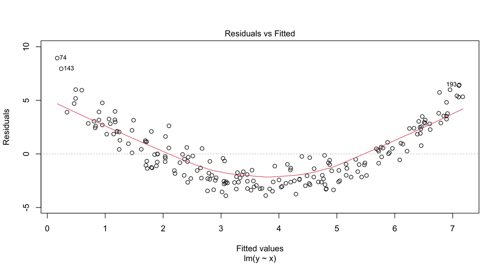

Figura 1: A curvatura sistemática sugere que a forma funcional da média condicional não foi adequadamente representada. Aqui conhecemos a causa porque construímos o processo gerador.

## Resíduos da relação quadrática

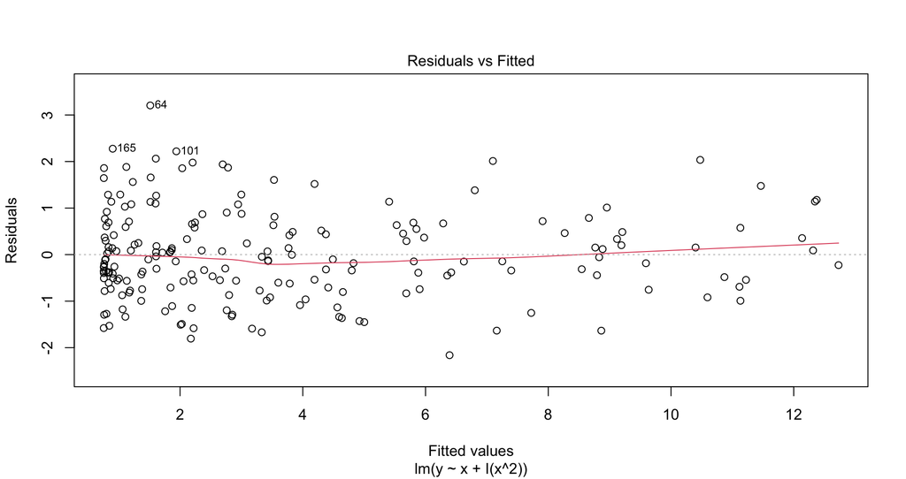

Figura 2: A estrutura curvilínea diminui substancialmente: os resíduos agora são mais compatíveis com uma nuvem sem padrão sistemático evidente.

## Simulando uma relação cúbica

Simulamos uma média condicional cúbica em $x$ e estimamos duas especificações.

```r
# fixa a semente para tornar a simulação reprodutível
set.seed(789)

# define o tamanho da amostra e simula a variável explicativa
n_cubico <- 200
x_cubico <- runif(n_cubico, -2, 2)

# simula erros com média zero e dispersão constante
erro_cubico <- rnorm(n_cubico, mean = 0, sd = 0.6)

# gera y segundo uma média condicional cúbica
y_cubico <- 1 + x_cubico + x_cubico^3 + erro_cubico

# organiza as variáveis simuladas em uma base de dados
dados_cubico <- data.frame(
  x = x_cubico,
  y = y_cubico
)

# estima uma especificação que omite o termo cúbico
modelo_cubico_linear <- lm(y ~ x, data = dados_cubico)

# estima a especificação correspondente ao processo gerador
modelo_cubico <- lm(y ~ x + I(x^3), data = dados_cubico)
```

## Outro padrão de forma funcional

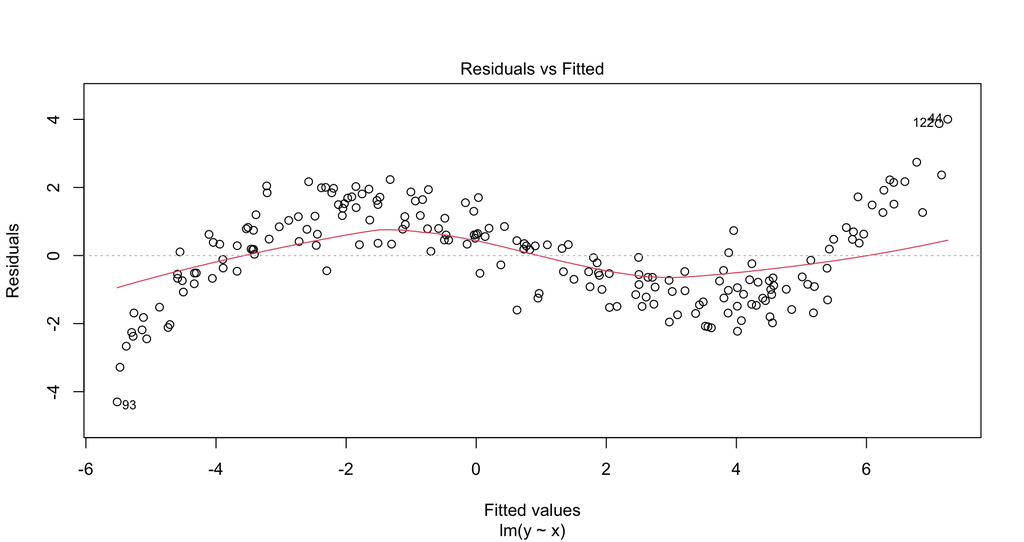

Figura 3: Os resíduos exibem uma estrutura sistemática distinta do caso quadrático, compatível com uma forma funcional inadequadamente representada. Nesta simulação, conhecemos a origem porque uma relação cúbica foi ajustada por uma especificação que inclui apenas o termo linear; em aplicações reais, o gráfico não identifica sozinho a forma correta.

## Quando a média condicional está adequadamente especificada

Incluímos agora o termo cúbico presente no processo gerador:

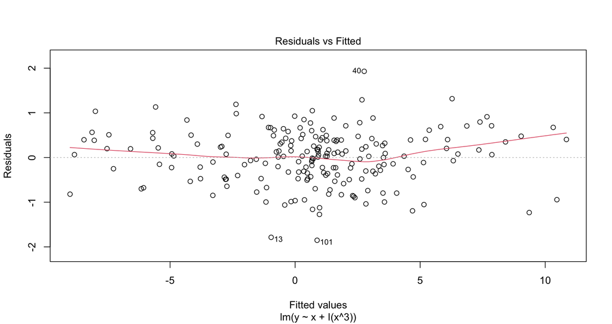

Figura 4: Ao representar adequadamente a forma da média condicional, a estrutura sistemática observada anteriormente desaparece. Os resíduos permanecem distribuídos em torno de zero sem um padrão sistemático evidente.

## Como usar o diagnóstico de resíduos?

Depois de estimar uma especificação candidata, examine os resíduos em busca de **estrutura sistemática que o modelo não representou**.

Se aparecer um padrão:

1. **investigue sua possível origem**;
2. considere se teoria, conhecimento substantivo e os dados justificam uma forma funcional alternativa;
3. estime uma especificação plausível e **examine novamente os resíduos**.

Nos exemplos simulados, sabíamos que faltavam $x^2$ ou $x^3$ porque conhecíamos o processo gerador.

**Em aplicações reais, o gráfico não informa qual termo deve ser acrescentado ao modelo.**

Se a estrutura sistemática desaparece, isso fornece **evidência favorável** à nova especificação quanto à forma da média condicional.

A ausência de padrão, porém, **não prova que o modelo esteja corretamente especificado**.

## Um padrão não identifica sozinho a causa

Nas simulações, conhecíamos a origem dos padrões porque **construímos o processo gerador**. Em aplicações reais, não temos essa informação.

- Um padrão sistemático nos resíduos indica **algo a investigar**.
- Sua aparência, isoladamente, não determina uma causa única.
- Diferentes mecanismos podem produzir padrões residuais semelhantes.

Por exemplo, uma forma funcional inadequada pode produzir sequências de resíduos também compatíveis com correlação dos erros.

**O gráfico sugere hipóteses para investigação; não identifica sozinho a origem do problema.**

## O diagnóstico não escolhe a especificação

Depois de identificar algo a investigar, surge uma questão diferente:

**O que deve — ou não deve — mudar na especificação do modelo?**

A decisão de reespecificar o modelo deve considerar, em conjunto:

- teoria e conhecimento substantivo;
- características dos dados;
- outras evidências econométricas pertinentes.

Como vimos em **Multicolinearidade e especificação**, o diagnóstico informa decisões de especificação; não as determina mecanicamente.

**Diagnosticar é reunir evidências para decidir, não obter uma resposta automática.**

## Normalidade e inferência no modelo linear

No modelo de regressão linear, a hipótese de normalidade estabelece que os **erros**, condicionalmente às regressoras, são normalmente distribuídos.

Uma **amostra finita** é simplesmente uma amostra com um número determinado de observações. Um resultado válido em amostras finitas não depende de aproximações que se tornam válidas apenas quando o tamanho da amostra cresce.

A normalidade tem um papel específico no modelo linear:

- **não é necessária**, por si só, para que os estimadores de MQO sejam não viesados ou para o teorema de Gauss-Markov;
- mantidas as demais hipóteses necessárias do modelo linear clássico, permite obter as **distribuições exatas**, em amostras finitas, que fundamentam os testes $t$ e $F$ e os intervalos de confiança usuais;
- em grandes amostras, sob condições apropriadas, a inferência pode ser fundamentada em resultados assintóticos mesmo sem normalidade exata.

A questão desta parte, portanto, não é usar a normalidade como um selo de validade do modelo, mas compreender **quando ela importa para a inferência** e **como investigar essa hipótese nos dados**.

## Como investigar a normalidade dos erros?

A importância da normalidade para a inferência depende do contexto, e sua avaliação não deve ser reduzida a uma decisão mecânica de “normal” ou “não normal”.

Antes de interpretar qualquer diagnóstico, precisamos considerar duas questões:

- o **tamanho da amostra**, porque ele afeta o papel das aproximações assintóticas na inferência;
- a normalidade é uma hipótese sobre os **erros**, que não são observados diretamente.

Na prática, investigaremos a normalidade dos erros a partir dos resíduos, combinando duas abordagens complementares:

- **diagnóstico gráfico:** o Q-Q plot permite observar **onde e como** a distribuição se afasta da referência normal;
- **testes formais:** Shapiro-Wilk e Jarque-Bera quantificam a evidência contra a hipótese de normalidade.

Nenhuma dessas ferramentas deve ser interpretada isoladamente como um **selo de normalidade**. O diagnóstico resulta da interpretação conjunta das evidências e de sua relevância para a inferência.

## O tamanho da amostra muda o papel da normalidade

À medida que a amostra cresce, resultados assintóticos podem fornecer boas aproximações para a inferência mesmo quando os erros não são exatamente normais.

Isso não produz, porém, uma regra mecânica:

- não existe um valor universal de $n$ que determine quando uma amostra passa a ser “grande”;
- a regra **$n > 30$** não deve ser tratada como um limite geral;
- em amostras menores, aproximações assintóticas podem ser menos confiáveis, tornando a hipótese de normalidade mais relevante quando desejamos inferência exata;
- ao mesmo tempo, uma amostra pequena contém menos informação sobre a forma da distribuição, de modo que os diagnósticos de normalidade também devem ser interpretados com cautela.

O tamanho da amostra deve fazer parte da **interpretação do diagnóstico**.

## Erros e resíduos no diagnóstico da normalidade

A hipótese de normalidade refere-se aos **erros** $\varepsilon_i$, mas eles não são observados.

Depois de estimarmos o modelo, observamos os **resíduos**:

$\hat e_i = y_i - \hat y_i$.

Por isso, usamos os resíduos como evidência empírica para investigar se a distribuição dos erros é compatível com a hipótese de normalidade.

Erros e resíduos, porém, **não são a mesma coisa**. Em grandes amostras, a diferença associada à estimação dos coeficientes tende a diminuir, tornando os resíduos uma aproximação mais próxima dos erros.

## O que o gráfico Q-Q compara

O **gráfico Q-Q normal** compara os quantis dos resíduos observados com os quantis esperados de uma distribuição normal.

- ordenamos os resíduos e os associamos aos **quantis teóricos** da normal;
- se houver compatibilidade aproximada com a normalidade, os pontos tendem a acompanhar uma **reta de referência**;
- desvios sistemáticos da reta, especialmente nas **caudas**, ajudam a localizar diferenças entre as distribuições.

Não esperamos alinhamento perfeito: o Q-Q plot é uma **ferramenta de diagnóstico**, não uma prova de normalidade.

## Exemplos de padrões em um Q-Q plot normal

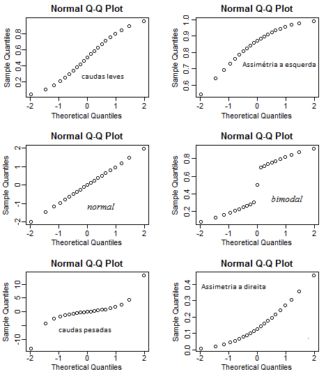

A **forma do afastamento do padrão aproximadamente linear** é informativa: pode sugerir assimetria, caudas mais leves ou mais pesadas e outras características da distribuição. Esses padrões são **referências para o diagnóstico**, não regras de classificação automática.

## Dados: `PublicSchools`

O conjunto `PublicSchools`, disponível no pacote `sandwich`, contém dados de **1979** sobre despesas com escolas públicas e renda per capita nos Estados Unidos (Fonte dos dados: Greene (1993)).

São **51 observações** e duas variáveis:

- `Expenditure`: despesa per capita com escolas públicas;
- `Income`: renda per capita.

Há uma informação ausente para Wisconsin. Por isso, trabalharemos com as **50 observações completas**.

```r
# carrega os dados
data("PublicSchools", package = "sandwich")

# mantém somente as observações completas
ps <- na.omit(PublicSchools)

# estima o modelo utilizado no diagnóstico
ps_lm <- lm(Expenditure ~ Income, data = ps)
```

## Por que usar resíduos padronizados?

O resíduo de uma observação é

$\hat e_i = y_i - \hat y_i$.

Depois da estimação, entretanto, os resíduos podem ter **variabilidades diferentes**, mesmo quando os erros do modelo têm variância constante.

Um **resíduo padronizado** expressa cada resíduo em relação à sua própria variabilidade estimada:

$r_i = \dfrac{\hat e_i}{\widehat{\operatorname{sd}}(\hat e_i)}$.

Isso coloca os resíduos em uma **escala comparável** para o diagnóstico.

No R, `rstandard()` calcula os resíduos padronizados de um modelo `lm`:

```r
# calcula os resíduos padronizados
ps_lm_residuos_pad <- rstandard(ps_lm)
```

O Q-Q produzido por `plot.lm()` também utiliza **resíduos padronizados**.

## Q-Q de `PublicSchools` com `plot()`

Para objetos `lm`, a função `plot()` oferece uma sequência de gráficos de diagnóstico.

Com `which = 2`, solicitamos o **Normal Q-Q**:

- quantis teóricos da normal no eixo horizontal;
- resíduos padronizados no eixo vertical.

```r
# solicita o gráfico Normal Q-Q
plot(ps_lm, which = 2)
```

## O Q-Q de `PublicSchools`

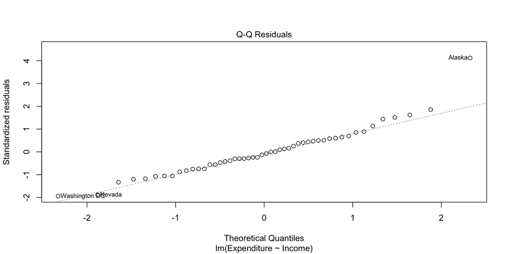

O centro acompanha razoavelmente a reta de referência, mas os desvios aumentam nas caudas. O maior afastamento ocorre na cauda superior, onde se destaca o Alasca.

## Q-Q com faixa de confiança

Podemos representar os mesmos **resíduos padronizados** com `ggpubr`.

Além da reta de referência, `ggqqplot()` acrescenta, por padrão, uma **faixa de confiança de 95%**.

```r
# produz o Q-Q dos resíduos padronizados
ggpubr::ggqqplot(ps_lm_residuos_pad) +
  xlab("Quantis teóricos da distribuição normal") +
  ylab("Resíduos padronizados")
```

A faixa ajuda a localizar os afastamentos mais evidentes da referência, mas não transforma o Q-Q plot em um teste formal de normalidade.

## Onde aparecem os principais afastamentos?

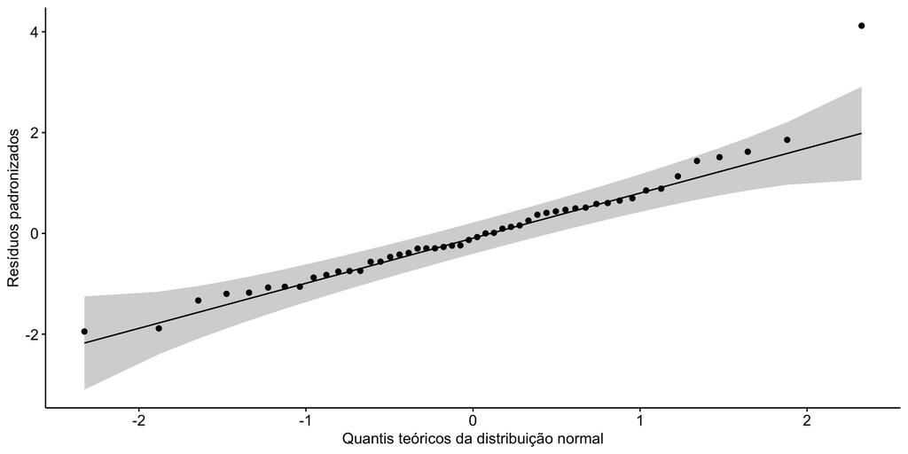

O centro permanece relativamente próximo da referência, enquanto os maiores afastamentos aparecem nas caudas.

O gráfico não fornece apenas uma resposta sobre “normalidade”: ele ajuda a identificar **onde** a distribuição dos resíduos se afasta mais claramente da referência normal.

## Shapiro-Wilk: hipótese e estatística

O teste de **Shapiro-Wilk** avalia a compatibilidade de uma distribuição com a normalidade.

$$H_0: Z \sim N(\mu,\sigma^2)
\qquad\text{contra}\qquad
H_1: Z \not\sim N(\mu,\sigma^2).$$

Para uma amostra $Z_1,\ldots,Z_n$, a estatística é

$$W =
\frac{
\left(\displaystyle\sum_{i=1}^{n} a_i Z_{(i)}\right)^2
}{
\displaystyle\sum_{i=1}^{n}(Z_i-\bar Z)^2
},$$

onde $Z_{(i)}$ são os valores ordenados e $a_i$ são pesos determinados a partir das estatísticas de ordem de uma amostra normal.

- valores menores de $W$ fornecem maior evidência contra $H_0$;
- sob $H_0$, a distribuição de $W$ depende de $n$ e **não possui uma distribuição de referência simples**, como $t$, $F$ ou $\chi^2$;
- por isso, o valor-$p$ é obtido por aproximações específicas para a distribuição de $W$.

## Shapiro-Wilk nos resíduos de `PublicSchools`

Como os erros não são observados, aplicamos o teste aos **resíduos de MQO**.

```r
# extrai os resíduos do modelo
ps_lm_residuos <- residuals(ps_lm)

# aplica o teste de Shapiro-Wilk
shapiro.test(ps_lm_residuos)
```

```
    Shapiro-Wilk normality test

data:  ps_lm_residuos
W = 0.94814, p-value = 0.02863
```

Para `PublicSchools`:

- $W \approx 0{,}948$;
- $p \approx 0{,}029$.

Ao nível de 5%, o resultado fornece **evidência contra a hipótese de normalidade**.

Há uma cautela importante: o Shapiro-Wilk foi formulado originalmente para uma amostra aleatória i.i.d., enquanto os resíduos são **estimados a partir da regressão**.

Resultados para modelos de regressão justificam assintoticamente o uso de testes de normalidade baseados nos resíduos. Ainda assim, tratamos o resultado como **evidência complementar ao diagnóstico gráfico**, e não como uma verificação exata, em amostra finita, da normalidade dos erros.

## O poder do teste também importa

O **poder** é a probabilidade de rejeitar $H_0$ quando os dados são gerados sob uma determinada alternativa, isto é, quando $H_0$ é falsa.

Resultados de Yap e Sim (2011) para $\alpha=0{,}05$:

| Distribuição alternativa | $n$ | Shapiro-Wilk | Jarque-Bera |
| --- | --- | --- | --- |
| $t(15)$ | 50 | 0,102 | 0,142 |
| Lognormal | 50 | 0,658 | 0,585 |
| Lognormal | 100 | 0,930 | 0,880 |

Os exemplos mostram duas características importantes:

- com o mesmo $n$, o poder pode variar muito conforme o **tipo de afastamento** da normalidade;
- para uma mesma alternativa, aumentar $n$ pode elevar substancialmente o poder.

Portanto, **não rejeitar $H_0$ não demonstra normalidade**: sob determinadas alternativas não normais, o teste pode ter **baixo poder** e, por isso, deixar de rejeitar $H_0$.

## Jarque-Bera: hipótese e estatística

O teste de **Jarque-Bera (JB)** avalia a normalidade a partir da **assimetria** e da **curtose** da distribuição.

Sob normalidade:

$$H_0: S = 0
\qquad\text{e}\qquad
K = 3,$$

contra

$$H_1: S \neq 0
\qquad\text{ou}\qquad
K \neq 3,$$

onde $S$ é a assimetria e $K$ é a curtose amostral.

A estatística do teste é

$$JB =
n\left[
\frac{S^2}{6}
+
\frac{(K-3)^2}{24}
\right].$$

Sob $H_0$, **assintoticamente**,

$$JB \overset{d}{\longrightarrow} \chi^2(2).$$

Valores elevados de $JB$ fornecem evidência contra $H_0$.

A referência $\chi^2(2)$ é **assintótica**, não uma distribuição exata em amostras finitas.

## Jarque-Bera nos resíduos de `PublicSchools`

Para implementar o **Jarque-Bera clássico** com `DescTools`:

```r
# aplica o teste clássico de Jarque-Bera
DescTools::JarqueBeraTest(
  ps_lm_residuos,
  robust = FALSE,
  method = "chisq"
)
```

```
    Jarque Bera Test

data:  ps_lm_residuos
X-squared = 18.178, df = 2, p-value = 0.0001129
```

Para `PublicSchools`:

- $JB \approx 18{,}18$;
- $p \approx 0{,}00011$.

O resultado fornece **forte evidência contra a hipótese de normalidade**.

**Por que `robust = FALSE`?**

`JarqueBeraTest()` utiliza `robust = TRUE` por padrão, o que calcula uma **modificação robusta do teste**.

Como apresentamos aqui a estatística clássica de Jarque-Bera, usamos `robust = FALSE`. Com `method = "chisq"`, o valor-p é calculado usando a referência assintótica $\chi^2(2)$.

## Diagnóstico de normalidade exige interpretação conjunta

Para `PublicSchools`, diferentes diagnósticos apontam na mesma direção:

- **Amostra:** 50 observações completas, sem um limiar universal que permita classificá-la mecanicamente como “grande”.
- **Q-Q plot:** o centro acompanha razoavelmente a referência, mas aparecem desvios importantes nas caudas, sobretudo na cauda superior.
- **Shapiro-Wilk:** fornece evidência complementar contra a normalidade.
- **Jarque-Bera:** também fornece forte evidência contra a normalidade, com a cautela de que sua referência é assintótica.

O Q-Q plot acrescenta algo que os $p$-valores não fornecem: mostra **onde e como** aparecem os principais afastamentos da referência normal.

O objetivo não é obter um selo de “normal” ou “não normal”.

Devemos perguntar se os afastamentos observados são relevantes para a **inferência que queremos realizar** e se revelam características dos dados ou do modelo que merecem investigação.

## O que fazer diante desse diagnóstico?

O Alasca apresenta um resíduo muito incomum. Isso não significa que devamos simplesmente excluir essa observação.

- verificar se a observação está correta e compreender suas características;
- reestimar o modelo sem o Alasca como **análise de sensibilidade**;
- comparar as estimativas e a inferência com e sem essa observação;
- se as conclusões mudarem de forma relevante, **reportar e discutir essa sensibilidade**.

Um resíduo muito incomum pode dominar alguns diagnósticos e dificultar a identificação de outros padrões. Por isso, na análise de sensibilidade, também é útil reexaminar os diagnósticos.

Isso não justifica, porém, remover observações sucessivamente apenas para obter resultados mais favoráveis.

**Um resíduo muito incomum significa necessariamente que a observação exerce grande influência sobre a regressão?**

## Referências

KOOP, G.; TOBIAS, J. L. Learning about Heterogeneity in Returns to Schooling. **Journal of Applied Econometrics**, v. 19, p. 827–849, 2004.

MCCULLOUGH, B. D. [Assessing the Reliability of Statistical Software: Part I](https://doi.org/10.1080/00031305.1998.10480597). **The American Statistician**, v. 52, n. 4, p. 358–366, 1998.

MCCULLOUGH, B. D.; HEISER, D. A. [On the Accuracy of Statistical Procedures in Microsoft Excel 2007](https://doi.org/10.1016/j.csda.2008.03.004). **Computational Statistics & Data Analysis**, v. 52, n. 10, p. 4570–4578, 2008.

MCCULLOUGH, B. D.; WILSON, B. [On the Accuracy of Statistical Procedures in Microsoft Excel 2003](https://doi.org/10.1016/j.csda.2004.06.016). **Computational Statistics & Data Analysis**, v. 49, n. 4, p. 1244–1252, 2005.

O’DONNELL, C. J.; GRIFFITHS, W. E. Estimating State-Contingent Production Frontiers. **American Journal of Agricultural Economics**, v. 88, n. 1, p. 249–266, 2006.

YAP, B. W.; SIM, C. H. [Comparisons of various types of normality tests](https://doi.org/10.1080/00949655.2010.520163). **Journal of Statistical Computation and Simulation**, v. 81, n. 12, p. 2141–2155, 2011.